# fishbone chart in R

chenzhiming

2024-10-9

# 1 背景介绍

持续进行高效质量管理相关素材内容准备。一直在纠结要不要在书中体现已经过时，或者被新工具取代的一些工具，考虑再三，还是花些时间做吧。实在话，鱼骨图，有够boring的。

鱼骨图，又名因果图，关键要素图，特性要因图，等等，由日本学者石川馨于1956年提出并推广，所以又叫石川图。那是一个思想和工具匮乏的年代。能提出这么一个管理工具，确实值得尊敬。

现如今，作为交付的工具，能替代这个图的载体太多了，以至于我们在日常工作中，几乎看不到所谓的鱼骨图这一古老的工具了，像极了工业革命过程中，传统的工具和方法逐步被淘汰。毕竟，现在小学生就有进行各种思维导图练习，软件工具也一大堆，真的没有人愿意用这个工具来画这个图了。

但这个工具背后的思维理念和方法论，是不会过时的。

鱼骨图的用途，怎么用等，这里不进行说明，毕竟不是专业的质量类文章。本文记录使用R语言ggplot2包绘制鱼骨图的过程。

同时，在图形绘制过程中，提供各类因素重要度，影响度等权重导入通道，并在鱼骨图的大类因素线型中进行体现，也算是对这一传统工具的微创新。

实践中，简单问题不需要使用这类图形，没有必要为了工具而工具；如真需使用，建议团队使用思维导图等现代工具；或者使用微软powerpoint中的结构图等，这些软件工具更适合团队进行头脑风暴等形式的讨论过程及结果输出。

本文为速记内容，对应图形为毛坯房状态。精修版本会在后续生成的绘制函数中体现。

# 2 样本数据准备

样本数据中，causes 仅考虑一层结构，不增加原因的分支。

```r
## 以list形式输入的样本
fb_data <- list(man = c("training","operating"),
                      environment = c("temprature","humidity","noise"),
                      machine = c("maintainment","repair"),
                      method = c("sop","standard"),
                      material = c( "spec","cosmetic", "length","width"),
                      measurement = c("calibrate","golden_sample"))
```

# 3 数据整理及绘图数据准备

```r
# 将list数据整理为dataframe数据
fb_df <- data.frame(effects = "fb_test",
                    casue_gr = rep(names(fb_data),
                                   lengths(fb_data)%>%
                                       unname()),
                    causes = fb_data %>%
                        unlist() %>%
                        unname(),
                    cause_gr_id = rep(1:length(names(fb_data)),
                                      lengths(fb_data)%>%
                                          unname()),
                    cause_weight = sample(1:10,15,replace = T))


# 增加绘图所需的数据项
fb_final_df <- fb_df %>%
    group_by(casue_gr) %>%
    mutate(rank_in_gr = rank(causes),
           cause_gr_weight = sum(cause_weight),
           max_rank_in_gr = max(rank_in_gr),
           x_start = 1-1/(2*(round(length(unique(.$casue_gr))/2)+1))*cause_gr_id,
           x_end = x_start - 0.15,
           y_start = 0,
           y_end = ifelse(cause_gr_id%%2==0,
                          -0.4,
                          0.4),
           cause_x_start = x_end + (0.15/(max_rank_in_gr + 1)*rank_in_gr),
           cause_y_start = ifelse(cause_gr_id%%2==0,
                                  y_end + (0.40/(max_rank_in_gr + 1)*rank_in_gr),
                                  y_end - (0.40/(max_rank_in_gr + 1)*rank_in_gr))
    )
```

# 4 绘制鱼骨图(草稿状态)

绘制的鱼骨图未添加箭头，文本外框等修饰元素。

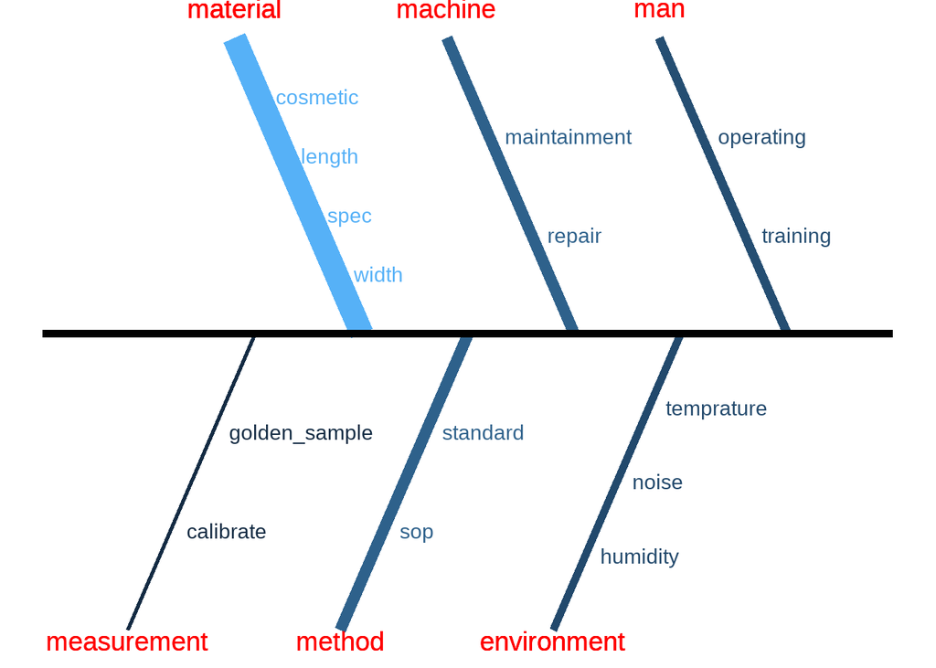

```r
fb_final_df %>%
    ggplot() +

    geom_segment(aes(x = x_start,
                     y = y_start,
                     xend = x_end,
                     yend = y_end,colour = cause_gr_weight, linewidth = cause_gr_weight))+
    geom_text(aes(x = cause_x_start+0.02,
                  y = cause_y_start,
                  label = causes,
                  hjust = 0,
                  color = cause_gr_weight),size = 8)+
    geom_text(aes(x = x_end,
                  y = ifelse(cause_gr_id%%2==0,y_end-0.01,y_end+0.01),
                  label = casue_gr,
                  hjust = 0.5,vjust =ifelse(cause_gr_id%%2==0,0.7,-0.7)),
              color = "red",size = 10) +
    geom_segment(aes(x = 0,y = 0, xend = 1, yend = 0),colour = "black",linewidth = 2)+
theme_void()+
    theme(legend.position = "none")
```

图形中可以看出，5M1E大类因素的6根主线粗细不一，粗线代表其权重高，也就是说其重要程度，或者优先级要高，或者其严重度更高，需要优先解决。

其实对应颜色也可以进行定制，这些基础设置会在后续函数化的代码中进行体现。

除了增加权重选项这个创新外，鱼骨图还可以根据输入提供summary，甚至提供一些关键建议，通过植入一些参数，形成所谓的专家系统级质量工具。

显然，做不到人工智能，到基于已有的经验数据或成果，根据输入的内容是可以对鱼骨图进行适度解读并输出解读结果的。这是可以在鱼骨图的输出交付中体现的。